# ANLY 512 - Problem Set 2

Visualizing Movie’s

Dean D’souza

2016-06-22

## Objectives

The objectives of this problem set is to gain experience working with data visualization as a tool for understanding unfamiliar data. To do this I want you to submit four *vis* that reveal something interesting about either the included `movies.csv` dataset. For each *vis*, include the code you used to create the plot (`echo=TRUE`), and a one paragraph description of what you found interesting. In most analyses the first plot you try will not be the most informative and you will need to make multiple improvements to get a polished plot. To show this process, for one of your 4 *vis*, provide 3-5 iterations that lead you to the final plot.

Finally, upon completion name your final output `.html` file as: `YourName_PS2_ANLY512-50_SU2016.html` and upload it to the “Problem Set 2”" assignment on Moodle.

## My Example

Below is my example for a multi-part question. I have also included an example of loading the data based on requests in last weeks class. I will provide the `movie_data.csv` check Moodle. Add your response in a similar fashion and submit following the directions above.

### Data Import & Cleanup

```r
library(dplyr)  # for easier filtering
```

```r
library(ggplot2)

dat <- read.csv("C:/Users/Dean/Desktop/DataViz/movie_data.csv")  # import the csv

str(dat)    # Look at the structure of the data frame
```

```
## 'data.frame':    3611 obs. of  16 variables:
##  $ Title           : Factor w/ 3575 levels "'I Know Where I'm Going!'",..: 162 268 294 457 491 504 703 909 948 1056 ...
##  $ id              : int  37 1 95 100 82 99 91 23 39 74 ...
##  $ released        : int  2010 2009 1989 2003 2014 2006 2010 2003 1994 2013 ...
##  $ Domestic        : Factor w/ 61 levels "","$244,082,982",..: 41 61 5 1 12 2 8 48 39 18 ...
##  $ International   : Factor w/ 61 levels "","$1,548,943,366",..: 55 9 5 1 34 11 18 43 22 33 ...
##  $ Worldwide       : Factor w/ 61 levels "","$1,002,891,358",..: 4 14 17 1 37 19 26 58 35 38 ...
##  $ Title.type      : Factor w/ 12 levels "Documentary",..: 2 2 2 2 2 2 2 2 2 2 ...
##  $ Directors       : Factor w/ 1925 levels "Aaron Blaise, Robert Walker",..: 315 744 1793 1820 120 904 1446 90 1566 55 ...
##  $ AVG.rating      : num  74 79 76 66 83 ...
##  $ IMDb.Rating     : num  7.4 7.9 7.6 6.6 8.3 7.2 7.6 8.1 8.7 8.8 ...
##  $ Rotten.Tom.     : Factor w/ 80 levels "10","100","16",..: NA NA NA NA NA NA NA 79 NA 77 ...
##  $ Metacritic      : Factor w/ 69 levels "100","28","29",..: NA NA NA NA NA NA NA 59 NA 65 ...
##  $ Runtime..mins.  : int  75 162 126 101 136 117 95 100 142 90 ...
##  $ Year            : num  1951 2009 1989 2003 2014 ...
##  $ Genres          : Factor w/ 773 levels "action","action, adventure",..: 270 46 126 389 54 261 283 253 683 697 ...
##  $ X..of.IMDb.votes: int  63718 596840 192085 202760 77440 157310 203915 406471 684507 32711 ...
```

```r
# Clean up some variables
dat$Domestic <- as.numeric(dat$Domestic)   # Convert these columns to numeric
dat$Worldwide <- as.numeric(dat$Worldwide)

dat2 <- filter(dat, Title.type == "Feature Film")
```

### Multi-step Visualization

Look at the distribution of earnines by release year.

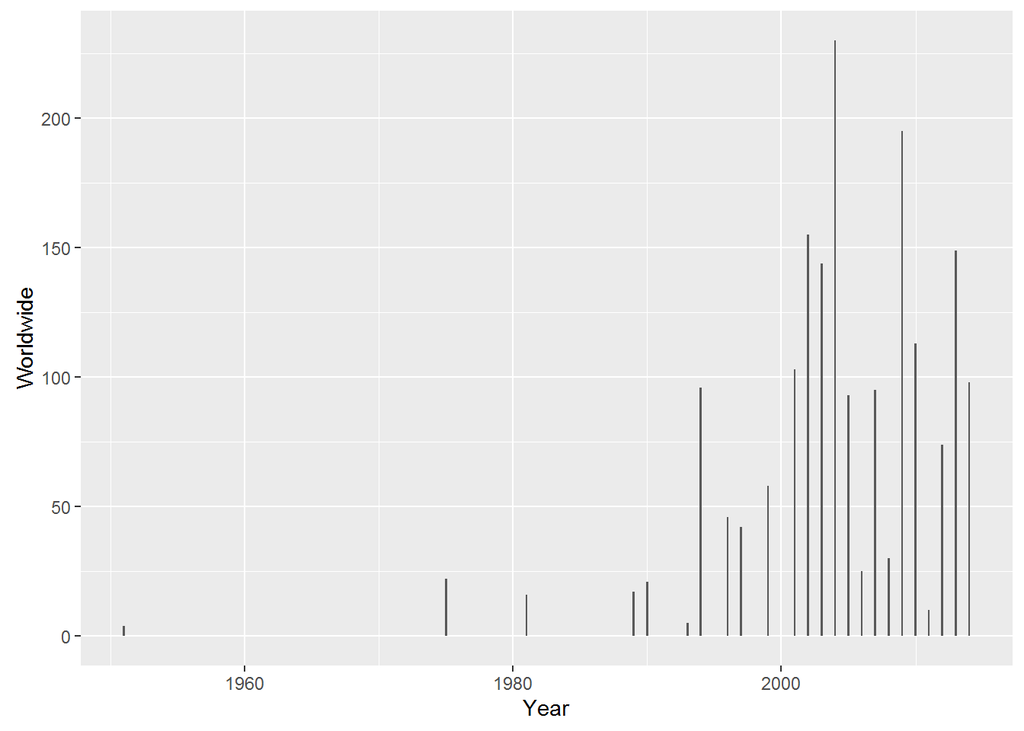

```r
ggplot(dat2, aes(Year, Worldwide)) +
  geom_bar(stat = "identity")
```

Lots of empty year earlier on, I will try just domestic earnings.

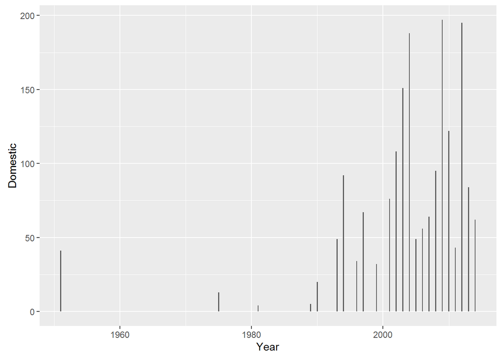

```r
ggplot(dat2, aes(Year, Domestic)) +
  geom_bar(stat = "identity")
```

No similar patterns. Looks like missing data early in the time series.

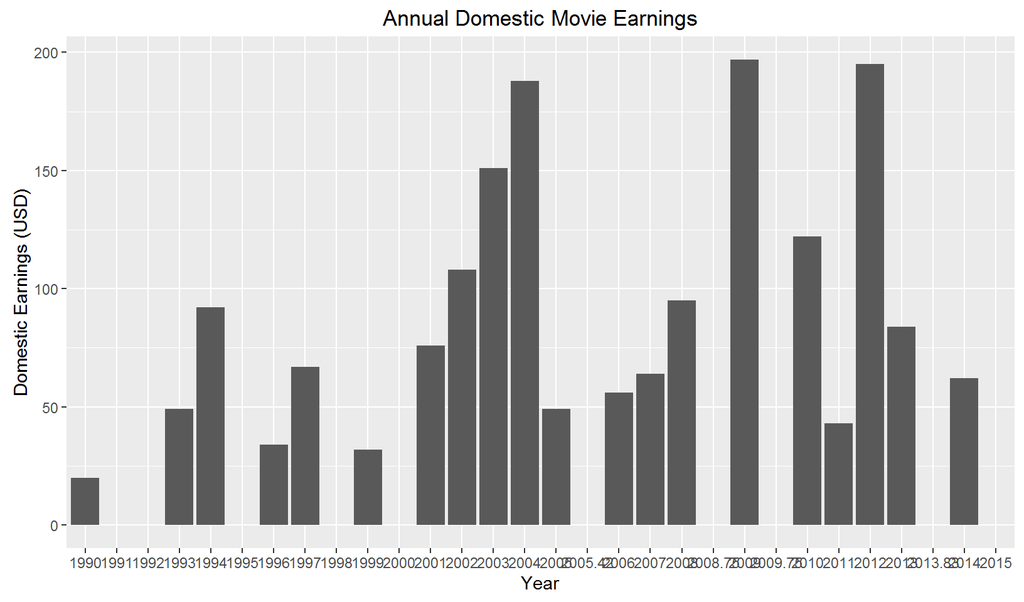

```r
dat3 <- filter(dat2, Year >= 1990)

ggplot(dat3, aes(factor(Year), Domestic)) +
  geom_bar(stat = "identity") +
  ggtitle("Annual Domestic Movie Earnings") +
  ylab("Domestic Earnings (USD)") +
  xlab("Year")
```

### Summary

There are several intersting details about this dataset I have identified. First there is excessive missing data points early in the time-series. A focus on data post-1990 is much more interesting. Second, the data seems to have inconsistent `Year` data because I have found abberrant year designations. In an analysis I would have to go back and ensure data is being aggregated to the year. Finally, and most interestingly domestic movie earnings have been rather inconsistent over the last twenty year.

## Visualization 1

For the first visualization we look at the Runtime in minutes for the entire data set.

### Multi-step Visualization

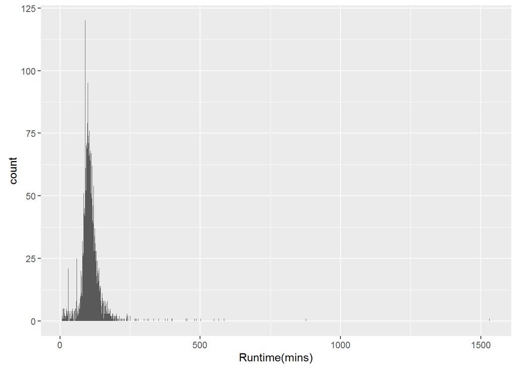

```
From the above plot we see that most of the cases in our data set have a runtime between 0 and 500 minutes.
We further scale the plot down to get a better look at the distribution.
```

```r
# A bit of additional clean up

dat$Title.type[dat$Title.type=="Mini-series"]<-"Mini-Series"

# Plotting the visualization

gp4<-ggplot(dat, aes(x=Runtime..mins.))
gp4+geom_bar(na.rm = TRUE)+xlab("Runtime(mins)")
```

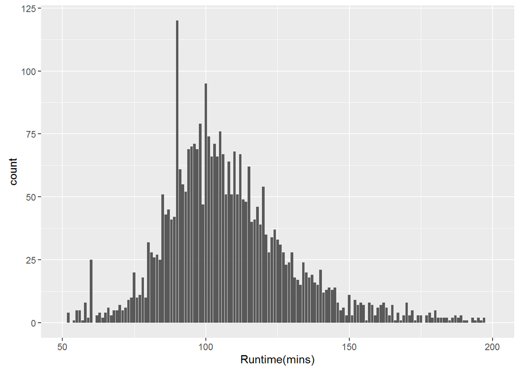

```r
gp4+geom_bar(na.rm = TRUE)+scale_x_continuous(limits=c(50,200))+xlab("Runtime(mins)")
```

While the above plot is useful, we can better summarize the data by using `geom_density()` function:

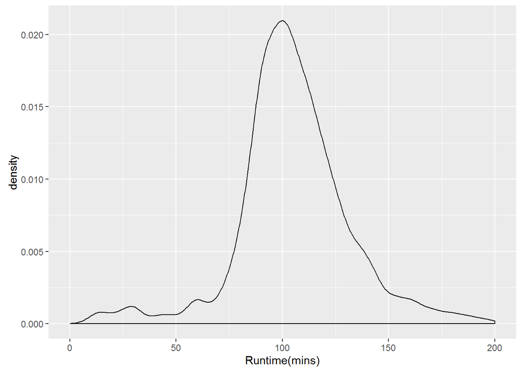

```r
gp4+geom_density(na.rm=TRUE)+scale_x_continuous(limits=c(0,200))+xlab("Runtime(mins)")
```

## Visualization 2

Here we take a look at the variation of IMDB ratings over the years while grouping based on the Title type.

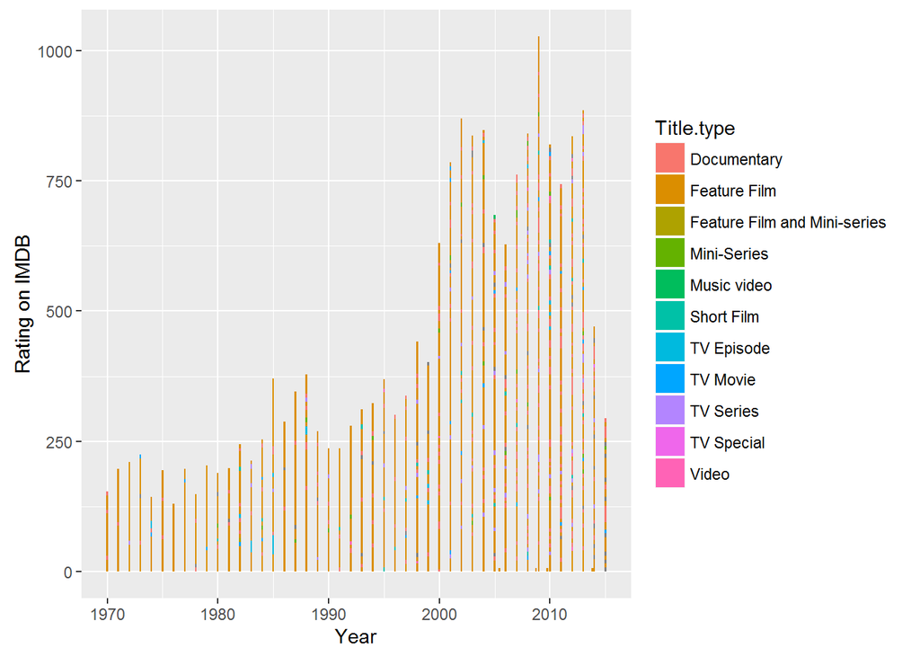

```r
dat.1<-filter(dat, Year>=1970 ,na.rm=TRUE)
gp3<-ggplot(dat.1, aes(x= Year, y= IMDb.Rating, fill= Title.type))
gp3+geom_bar(stat="identity", position="stack")+xlab("Year")+ylab("Rating on IMDB")
```

## Visualization 3

In the following visualization we try to see if there is a relationship between the IMDB ratings and Average Ratings of the various cases. We also divide this based on the Title.type for a better view of variation across this factor.

[figure not shown]

```r
gp1<-ggplot(dat, aes(x=IMDb.Rating, y=AVG.rating, colour=Title.type))
gp1+geom_point(na.rm=TRUE)+facet_wrap(~Title.type)+xlab("Ratings on IMDB")+ylab("Average Rating")
```

Based on the plot we can see that overall it would seem that there is a linear relationship between the IMDB ratings and Average ratings over the various groups. However in the case of “Feature Film” and of “Documentaries”, we see a lot of variation.

## Visualization 4

The following visualization takes a look at the variation of Average Ratings over the years for the various groups of Title.type.

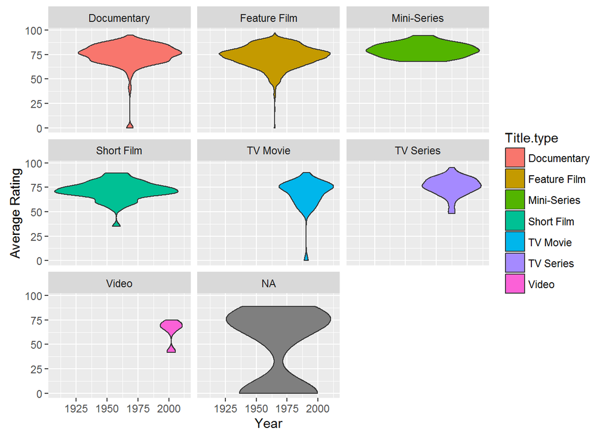

```r
#dat$Rotten.Tom.<-as.numeric(dat$Rotten.Tom.)

#  Trying the exclude certain Title.type so as to only view proper violin plots
dat.2<-filter(dat,!(grepl("Feature Film and Mini-series|Music video|TV Episode|TV Special|NA",Title.type)))

#dat.3<-filter(dat.1, Rotten.Tom.>0,na.rm=TRUE)

# plotting the violin plots by faceting over Title.type
gp2<-ggplot(dat.2, aes(x= Year , y= AVG.rating , fill= Title.type))
gp2+geom_violin(na.rm=TRUE)+facet_wrap(~Title.type,drop = TRUE)+xlab("Year")+ylab("Average Rating")
```

The above plot gives us an idea about the distribution of Average ratings over the years fot the varuious Title.type.

## Summary

The above visualizations help us to get a better understanding of the data set and how the various cases are distributed. The ggplot2 package provides a number of useful visualization tools that can help with depicting information better as well and the dplyr package helps to better structure the data for the visualizations. This document can also be found on [GitHub](https://github.com/DeanDsouza25/ANLY_512-50_SU2016/tree/master/Assignment_2)